# Time series

Peter Ralph

Advanced Biological Statistics

# Time series data

## Time series

A *time series* is a sequence of observations
$$\begin{aligned}
(y_1, y_2, \ldots, y_N) ,
\end{aligned}$$
that were taken at some set of *times*
$$\begin{aligned}
t_1 < t_2 < \cdots < t_N .
\end{aligned}$$

Goals might be to:

- describe patterns
- discover trends
- quantify correlations
- predict future values

## The thing about time

Many statistical methods assume *independence* of observations.

Nearby observations in a time series are *definately* not.

Today: a *mechanistic model*.

# An oscillator

## A discrete, noisy oscillator

Suppose we have regular, noisy observations from a discrete, noisy oscillator.

The system itself does
$$\begin{aligned}
x_{t+1} - x_t &= \alpha y_t + \Normal(0, \sigma_{xy}) \\
y_{t+1} - y_t &= - \beta x_t + \Normal(0, \sigma_{xy})
\end{aligned}$$
but we only get to observe
$$\begin{aligned}
X_t &= x_t + \Normal(0, \sigma_\epsilon) \\
Y_t &= y_t + \Normal(0, \sigma_\epsilon) .
\end{aligned}$$

*Note:* $\sigma_{xy}$ is *process noise*, and $\sigma_\epsilon$ is *observation noise*.

## Some data

`data/osc_data.csv`

```r
head(
     osc_data <- read.csv("data/osc_data.csv", header=TRUE)
)
```

```
##           X          Y
## 1 3.0294511  0.1077934
## 2 2.1624268  0.7287783
## 3 3.4787385 -0.2474969
## 4 0.8519628  0.1390850
## 5 2.8182162 -1.1920302
## 6 3.8786329 -0.1581520
```

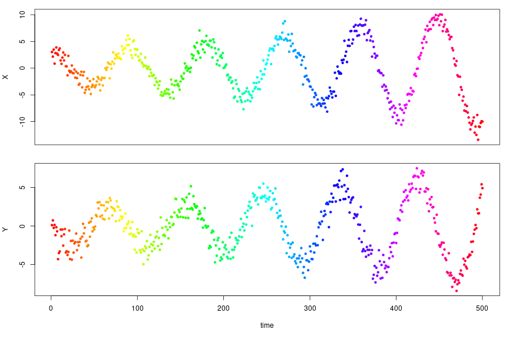

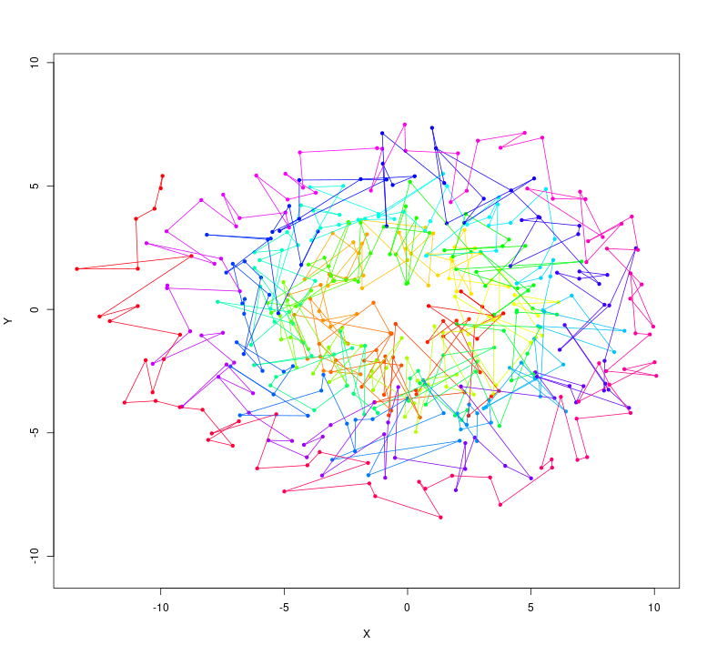

## Our model-building plan

0. Write down a model.
1. Simulate from the model.
2. Check the simulations kinda look like the real data.
3. Write a method to fit the model.
4. Check the method correctly infers the true parameters of simulated data.
5. Fit the model to the real data.
6. Check that posterior predictive simulations look like the real data.
7. Celebrate!

# Simulate, and check it looks like the real data

```r
true_osc <- list(alpha=.1,
                 beta=.05,
                 sigma_xy=.01,
                 sigma_eps=1)
N <- 500
xy <- matrix(nrow=N, ncol=2)
xy[1,] <- c(3,0)
for (k in 1:(N-1)) {
    xy[k+1,] <- (xy[k,]
        + c(true_osc$alpha * xy[k,2],
            (-1) * true_osc$beta * xy[k,1])
        + rnorm(2, 0, true_osc$sigma_xy))
}
XY <- (xy
   + rnorm(N*2, 0, true_osc$sigma_eps))
```

The system itself does
$$\begin{aligned}
&x_{t+1} - x_t = \alpha y_t \\
&\qquad {} + \Normal(0, \sigma_{xy}) \\
&y_{t+1} - y_t = - \beta x_t \\
&\qquad {} + \Normal(0, \sigma_{xy})
\end{aligned}$$
but we only get to observe
$$\begin{aligned}
X_t &= x_t + \Normal(0, \sigma_\epsilon) \\
Y_t &= y_t + \Normal(0, \sigma_\epsilon) .
\end{aligned}$$

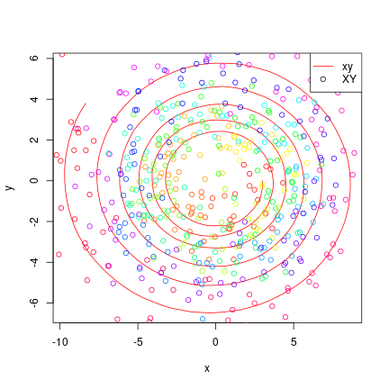

## Exercise:

1. Suppose $\alpha = \beta = 0.1$ and $\sigma_\epsilon = 1$ and $\sigma_{xy} = 0.01$. How well do you think we can estimate $\alpha$ and $\beta$? (Play around with them, to see how much they change the data.)
2. What if $\sigma_{\epsilon} = 10$?

Plotting code:

```r
plot(xy, type='l', col='red', xlab='x', ylab='y')
points(XY, col=rainbow(N))
legend("topright", lty=c(1, NA), pch=c(NA,1), col=c("red","black"),
       legend=c("xy", "XY"))
```

# Write a Stan model, and check it works.

## A Stan block

```r
osc_block <- "
data {
    int N;
    vector[N] X;
    vector[N] Y;
}
parameters {
    real alpha;
    real beta;
    real<lower=0> sigma_xy;
    real<lower=0> sigma_eps;
    vector[N] x;
    vector[N] y;
}
model {
    x[1] ~ normal(0, 5);
    y[1] ~ normal(0, 5);
    x[2:N] ~ normal(x[1:(N-1)] + alpha * y[1:(N-1)], sigma_xy);
    y[2:N] ~ normal(y[1:(N-1)] - beta * x[1:(N-1)], sigma_xy);
    X ~ normal(x, sigma_eps);
    Y ~ normal(y, sigma_eps);
    alpha ~ normal(0, 1);
    beta ~ normal(0, 1);
    sigma_xy ~ normal(0, 1);
    sigma_eps ~ normal(0, 1);
}
"
osc_model <- stan_model(model_code=osc_block)
```

```r
osc_fit <- sampling(osc_model,
                    data=list(N=N,
                              X=XY[,1],
                              Y=XY[,2]),
                    iter=1000, chains=3,
                    control=list(max_treedepth=14))
```

## How’d we do?

```r
cbind(truth=c(true_osc$alpha, true_osc$beta, true_osc$sigma_xy, true_osc$sigma_eps),
      rstan::summary(osc_fit, pars=c("alpha", "beta", "sigma_xy", "sigma_eps"))$summary)
```

```
##           truth       mean      se_mean           sd        2.5%        25%        50%        75%      97.5%       n_eff     Rhat
## alpha      0.10 0.09950010 6.169861e-05 0.0018347714 0.096044115 0.09820606 0.09951923 0.10067989 0.10316309  884.327461 1.000051
## beta       0.05 0.05011448 3.090389e-05 0.0009264783 0.048325695 0.04951725 0.05009466 0.05075242 0.05192722  898.760907 1.000292
## sigma_xy   0.01 0.02062393 4.212708e-03 0.0065187639 0.009178815 0.01614820 0.01977550 0.02630435 0.03244747    2.394461 2.132853
## sigma_eps  1.00 0.99985662 6.835608e-04 0.0233698082 0.957753401 0.98408138 0.99918806 1.01575953 1.04698140 1168.842337 1.006658
```

Here is a density plot of 100 estimated trajectories (of `x` and `y`) from the Stan fit, with the true values in red.

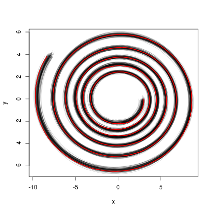

# Check it works some more

## A noisier oscillator

Let’s try that again, with more noise.

Here’s what this looks like.

```r
true_osc2 <- list(alpha=.1,
                 beta=.05,
                 sigma_xy=2.0,
                 sigma_eps=4.0)
xy2 <- matrix(nrow=N, ncol=2)
xy2[1,] <- c(3,0)
for (k in 1:(N-1)) {
    xy2[k+1,] <- (xy2[k,]
                + c(true_osc2$alpha * xy2[k,2],
                    (-1) * true_osc2$beta * xy2[k,1])
                + rnorm(2, 0, true_osc2$sigma_xy))
}
XY2 <- xy2 + rnorm(N*2, 0, true_osc2$sigma_eps)
```

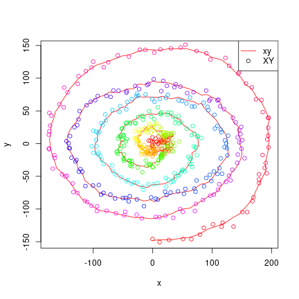

```r
osc_fit2 <- sampling(osc_model,
                    data=list(N=N,
                              X=XY2[,1],
                              Y=XY2[,2]),
                    iter=1000, chains=3,
                    control=list(max_treedepth=12))
```

## How’d we do?

```r
cbind(truth=c(true_osc2$alpha, true_osc2$beta, true_osc2$sigma_xy, true_osc2$sigma_eps),
      rstan::summary(osc_fit2, pars=c("alpha", "beta", "sigma_xy", "sigma_eps"))$summary)
```

```
##           truth       mean      se_mean          sd       2.5%        25%        50%       75%      97.5%     n_eff      Rhat
## alpha      0.10 0.10123799 3.935719e-05 0.001642870 0.09801558 0.10010042 0.10127181 0.1023376 0.10451309 1742.4410 0.9997534
## beta       0.05 0.05141579 3.018645e-05 0.001181041 0.04909184 0.05061257 0.05142453 0.0522106 0.05373877 1530.7559 1.0006137
## sigma_xy   2.00 2.07727845 1.256498e-02 0.142052935 1.81357843 1.97775757 2.07045167 2.1710405 2.36771597  127.8135 1.0202276
## sigma_eps  4.00 3.88583351 4.596211e-03 0.121267863 3.65422247 3.79886698 3.88400777 3.9680865 4.12732245  696.1319 1.0011903
```

Here is a density plot of 100 estimated trajectories (of `x` and `y`) from the Stan fit, with the true values in red.

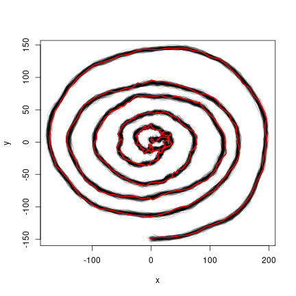

# Fit the model to real data, and do posterior predictive checks

## Fit the model, again

```r
real_fit <- sampling(osc_model,
                    data=list(N=nrow(osc_data),
                              X=osc_data[,1],
                              Y=osc_data[,2]),
                    iter=1000, chains=3,
                    control=list(max_treedepth=14))
```

## Check for convergence

```r
rstan::summary(real_fit)$summary
```

```
##                    mean      se_mean           sd          2.5%           25%           50%           75%         97.5%       n_eff      Rhat
## alpha      1.008104e-01 6.418202e-05 1.772977e-03  9.736394e-02  9.962001e-02  1.008142e-01  1.019818e-01  1.043653e-01  763.096364 1.0013730
## beta       4.928773e-02 3.214881e-05 8.725226e-04  4.753006e-02  4.872654e-02  4.927210e-02  4.984254e-02  5.105128e-02  736.586090 1.0006042
## sigma_xy   1.645999e-02 3.389622e-03 7.502791e-03  6.211528e-03  1.129008e-02  1.447433e-02  2.096380e-02  3.385537e-02    4.899403 2.2999149
## sigma_eps  1.042205e+00 5.971120e-04 2.503574e-02  9.938256e-01  1.025483e+00  1.042920e+00  1.058784e+00  1.091258e+00 1757.960833 0.9993080
## x[1]       3.107086e+00 3.518795e-03 1.360745e-01  2.840554e+00  3.016827e+00  3.106453e+00  3.192883e+00  3.380660e+00 1495.427984 1.0007943
## x[2]       3.099409e+00 3.506638e-03 1.354533e-01  2.833730e+00  3.012462e+00  3.094816e+00  3.185125e+00  3.379834e+00 1492.096743 1.0012713
## x[3]       3.075726e+00 3.494210e-03 1.331047e-01  2.818874e+00  2.987542e+00  3.072988e+00  3.161315e+00  3.352671e+00 1451.070481 1.0018495
## x[4]       3.036724e+00 3.533753e-03 1.324260e-01  2.782878e+00  2.950806e+00  3.033343e+00  3.121177e+00  3.310836e+00 1404.346102 1.0029472
## x[5]       2.982827e+00 3.514757e-03 1.314889e-01  2.737742e+00  2.894701e+00  2.979902e+00  3.069057e+00  3.255201e+00 1399.547303 1.0033595
## x[6]       2.913907e+00 3.616998e-03 1.312431e-01  2.670807e+00  2.823704e+00  2.911142e+00  2.999143e+00  3.184095e+00 1316.608320 1.0044145
## x[7]       2.830164e+00 3.685223e-03 1.315823e-01  2.578404e+00  2.741398e+00  2.828441e+00  2.914813e+00  3.099346e+00 1274.874981 1.0049492
## x[8]       2.729832e+00 3.760844e-03 1.307744e-01  2.478021e+00  2.641777e+00  2.728533e+00  2.815765e+00  2.995845e+00 1209.135534 1.0057213
## x[9]       2.618192e+00 3.787475e-03 1.291662e-01  2.366196e+00  2.533631e+00  2.615702e+00  2.700148e+00  2.882476e+00 1163.049564 1.0063610
## x[10]      2.492177e+00 3.815261e-03 1.289472e-01  2.236825e+00  2.406810e+00  2.490684e+00  2.575140e+00  2.749641e+00 1142.287991 1.0065553
## x[11]      2.352717e+00 4.006726e-03 1.288760e-01  2.092560e+00  2.267632e+00  2.355709e+00  2.438343e+00  2.605885e+00 1034.581238 1.0069255
## x[12]      2.201063e+00 3.948860e-03 1.286762e-01  1.933400e+00  2.115999e+00  2.202531e+00  2.286072e+00  2.448990e+00 1061.824452 1.0072516
## x[13]      2.038720e+00 3.981464e-03 1.299064e-01  1.766290e+00  1.951793e+00  2.040601e+00  2.124752e+00  2.286363e+00 1064.572953 1.0071480
## x[14]      1.864565e+00 3.903805e-03 1.305053e-01  1.592583e+00  1.778774e+00  1.865998e+00  1.947292e+00  2.116231e+00 1117.583276 1.0070097
## x[15]      1.680345e+00 3.909602e-03 1.298446e-01  1.414329e+00  1.594920e+00  1.685766e+00  1.764759e+00  1.929487e+00 1103.018437 1.0069442
## x[16]      1.487391e+00 3.833383e-03 1.298002e-01  1.214490e+00  1.402540e+00  1.489379e+00  1.573531e+00  1.737385e+00 1146.532015 1.0067759
## x[17]      1.285047e+00 3.841861e-03 1.301201e-01  1.013213e+00  1.202769e+00  1.285604e+00  1.371424e+00  1.535560e+00 1147.111371 1.0067345
## x[18]      1.075949e+00 3.699505e-03 1.280564e-01  8.133037e-01  9.940031e-01  1.076503e+00  1.161291e+00  1.325640e+00 1198.161969 1.0068995
## x[19]      8.606423e-01 3.680938e-03 1.279648e-01  6.000902e-01  7.785523e-01  8.610872e-01  9.463143e-01  1.114348e+00 1208.549031 1.0071411
## x[20]      6.407060e-01 3.607135e-03 1.279770e-01  3.793225e-01  5.579321e-01  6.420767e-01  7.238907e-01  8.902760e-01 1258.749178 1.0068350
## x[21]      4.161159e-01 3.607167e-03 1.284946e-01  1.525855e-01  3.345841e-01  4.160163e-01  5.025594e-01  6.695655e-01 1268.927964 1.0057863
## x[22]      1.888027e-01 3.573736e-03 1.288059e-01 -7.255504e-02  1.051527e-01  1.903539e-01  2.729899e-01  4.387171e-01 1299.052683 1.0047782
## x[23]     -4.136401e-02 3.508199e-03 1.285330e-01 -3.016729e-01 -1.253114e-01 -3.811313e-02  4.376542e-02  2.041607e-01 1342.335564 1.0044477
## x[24]     -2.707266e-01 3.435747e-03 1.281554e-01 -5.288703e-01 -3.512253e-01 -2.701873e-01 -1.850773e-01 -2.195330e-02 1391.334402 1.0038327
## x[25]     -5.010298e-01 3.360184e-03 1.277836e-01 -7.521077e-01 -5.815825e-01 -4.994760e-01 -4.178094e-01 -2.568108e-01 1446.186188 1.0032905
## x[26]     -7.291316e-01 3.331367e-03 1.268865e-01 -9.774206e-01 -8.120411e-01 -7.275615e-01 -6.453805e-01 -4.844382e-01 1450.726318 1.0020903
## x[27]     -9.547300e-01 3.336190e-03 1.267762e-01 -1.203520e+00 -1.037522e+00 -9.517874e-01 -8.725357e-01 -7.152408e-01 1444.021662 1.0018606
## x[28]     -1.178093e+00 3.271618e-03 1.258812e-01 -1.428054e+00 -1.257883e+00 -1.177543e+00 -1.095211e+00 -9.327244e-01 1480.459257 1.0011758
## x[29]     -1.394674e+00 3.278969e-03 1.250214e-01 -1.642283e+00 -1.474202e+00 -1.394159e+00 -1.312830e+00 -1.150445e+00 1453.765881 1.0004930
## x[30]     -1.605554e+00 3.279691e-03 1.248425e-01 -1.848101e+00 -1.681984e+00 -1.605745e+00 -1.526267e+00 -1.349696e+00 1448.967822 1.0000689
## x[31]     -1.810541e+00 3.246824e-03 1.243952e-01 -2.058875e+00 -1.887601e+00 -1.810585e+00 -1.731352e+00 -1.560644e+00 1467.877808 1.0002406
## x[32]     -2.008076e+00 3.243757e-03 1.237519e-01 -2.256711e+00 -2.083049e+00 -2.007729e+00 -1.927442e+00 -1.761827e+00 1455.482942 0.9999995
## x[33]     -2.196650e+00 3.259884e-03 1.234480e-01 -2.451780e+00 -2.273221e+00 -2.199531e+00 -2.117927e+00 -1.944540e+00 1434.048932 1.0001364
## x[34]     -2.374978e+00 3.266874e-03 1.234816e-01 -2.624927e+00 -2.450896e+00 -2.380508e+00 -2.296221e+00 -2.123379e+00 1428.694865 1.0001877
## x[35]     -2.542592e+00 3.258095e-03 1.223090e-01 -2.784191e+00 -2.622365e+00 -2.545099e+00 -2.466141e+00 -2.291253e+00 1409.255473 1.0006688
```

[output cut: 951 more lines]

```
## y[487]    -2.520288e+00 8.124840e-03 1.200852e-01 -2.760269e+00 -2.596629e+00 -2.518742e+00 -2.441069e+00 -2.291026e+00  218.448578 1.0292001
## y[488]    -2.019114e+00 8.060611e-03 1.206091e-01 -2.259215e+00 -2.095846e+00 -2.016106e+00 -1.940047e+00 -1.791119e+00  223.884651 1.0286428
## y[489]    -1.504946e+00 7.700196e-03 1.212717e-01 -1.748904e+00 -1.579346e+00 -1.503272e+00 -1.423361e+00 -1.270798e+00  248.036169 1.0273398
## y[490]    -9.794153e-01 6.056667e-03 1.226861e-01 -1.225863e+00 -1.055123e+00 -9.766534e-01 -8.977862e-01 -7.439109e-01  410.320904 1.0218263
## y[491]    -4.464521e-01 5.341470e-03 1.230739e-01 -6.915370e-01 -5.248580e-01 -4.433708e-01 -3.638398e-01 -2.151261e-01  530.897487 1.0191144
## y[492]     9.188079e-02 3.957601e-03 1.239158e-01 -1.501190e-01  1.398457e-02  9.465974e-02  1.738274e-01  3.267843e-01  980.369146 1.0132733
## y[493]     6.325283e-01 3.796911e-03 1.262945e-01  3.775100e-01  5.539319e-01  6.352488e-01  7.196832e-01  8.717249e-01 1106.389099 1.0099505
## y[494]     1.173381e+00 3.681869e-03 1.282797e-01  9.113382e-01  1.090559e+00  1.176296e+00  1.261647e+00  1.418311e+00 1213.889571 1.0059965
## y[495]     1.711463e+00 3.624300e-03 1.308725e-01  1.452508e+00  1.627420e+00  1.712799e+00  1.799680e+00  1.958630e+00 1303.912502 1.0029627
## y[496]     2.243650e+00 3.684176e-03 1.340014e-01  1.977415e+00  2.157301e+00  2.244522e+00  2.333275e+00  2.509759e+00 1322.933931 1.0007402
## y[497]     2.767775e+00 3.750595e-03 1.361182e-01  2.505948e+00  2.677826e+00  2.770351e+00  2.856928e+00  3.033508e+00 1317.139976 0.9998065
## y[498]     3.278941e+00 3.887059e-03 1.389878e-01  3.010931e+00  3.189030e+00  3.279934e+00  3.370113e+00  3.554967e+00 1278.529731 0.9998958
## y[499]     3.777621e+00 4.042767e-03 1.399243e-01  3.506428e+00  3.688005e+00  3.777031e+00  3.870539e+00  4.053012e+00 1197.923392 1.0008993
## y[500]     4.258251e+00 4.201316e-03 1.429225e-01  3.976754e+00  4.164305e+00  4.257375e+00  4.353300e+00  4.547949e+00 1157.258676 1.0020165
## lp__       3.154266e+03 2.042118e+02 4.474804e+02  2.340477e+03  2.815106e+03  3.176430e+03  3.427675e+03  4.028442e+03    4.801602 2.3592771
```

## Posterior predictive sampling

```r
sim_data <- function (x0, y0, alpha, beta, sigma_xy, sigma_eps, N) {
    xy <- matrix(nrow=N, ncol=2)
    xy[1,] <- c(x0, y0)
    for (k in 1:(N-1)) {
        xy[k+1,] <- (xy[k,]
                    + c(alpha * xy[k,2],
                        (-1) * beta * xy[k,1])
                    + rnorm(2, 0, sigma_xy))
    }
    XY <- xy + rnorm(N*2, 0, sigma_eps)
    return(XY)
}
```

```r
post <- rstan::extract(real_fit)
nsims <- 50
pp_XY <- array(NA, dim=c(N, 2, nsims))
for (k in 1:nsims) {
    pp_XY[,,k] <- sim_data(
                           x0=post$x[k,1],
                           y0=post$y[k,1],
                           alpha=post$alpha[k],
                           beta=post$beta[k],
                           sigma_xy=post$sigma_xy[k],
                           sigma_eps=post$sigma_eps[k],
                           N=N)
}
```

Real data in red:

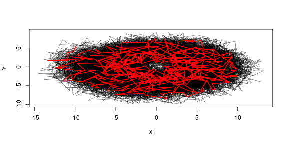

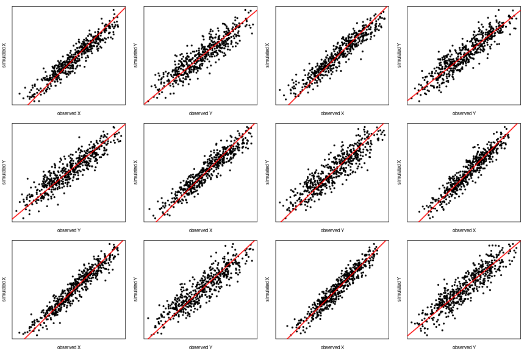

# Doing this in brms

*Note:* this is an *autoregressive* model with *measurement error*, and it’s (now) possible to fit this model in brms, using a [multivariate model](https://paul-buerkner.github.io/brms/reference/brmsformula.html), [`ar()` terms](https://paul-buerkner.github.io/brms/reference/ar.html) for the “autoregressive” part, and [`mi()` terms](https://paul-buerkner.github.io/brms/reference/mi.html) for the measurement error:

```r
(ar_fit <- brm( mvbf(
        Y | mi() ~ 0 + X + ar(),
        X | mi() ~ 0 + Y + ar(),
        rescor=FALSE
    ),
    data=osc_data, chains=2
))
```

```
##  Family: MV(gaussian, gaussian)
##   Links: mu = identity; sigma = identity
##          mu = identity; sigma = identity
## Formula: Y | mi() ~ 0 + X + ar()
##          X | mi() ~ 0 + Y + ar()
##    Data: osc_data (Number of observations: 500)
##   Draws: 2 chains, each with iter = 2000; warmup = 1000; thin = 1;
##          total post-warmup draws = 2000
##
## Correlation Structures:
##         Estimate Est.Error l-95% CI u-95% CI Rhat Bulk_ESS Tail_ESS
## ar_Y[1]     0.91      0.02     0.87     0.95 1.00     2744     1401
## ar_X[1]     0.95      0.01     0.92     0.98 1.00     2727     1543
##
## Population-Level Effects:
##     Estimate Est.Error l-95% CI u-95% CI Rhat Bulk_ESS Tail_ESS
## Y_X     0.02      0.04    -0.06     0.09 1.00     2400     1605
## X_Y     0.02      0.05    -0.07     0.12 1.00     2391     1481
##
## Family Specific Parameters:
##         Estimate Est.Error l-95% CI u-95% CI Rhat Bulk_ESS Tail_ESS
## sigma_Y     1.44      0.05     1.36     1.53 1.00     2681     1461
## sigma_X     1.58      0.05     1.48     1.68 1.00     2170     1631
##
## Draws were sampled using sampling(NUTS). For each parameter, Bulk_ESS
## and Tail_ESS are effective sample size measures, and Rhat is the potential
## scale reduction factor on split chains (at convergence, Rhat = 1).
```

```r
ar_fit
```

```
##  Family: MV(gaussian, gaussian)
##   Links: mu = identity; sigma = identity
##          mu = identity; sigma = identity
## Formula: Y | mi() ~ 0 + X + ar()
##          X | mi() ~ 0 + Y + ar()
##    Data: osc_data (Number of observations: 500)
##   Draws: 2 chains, each with iter = 2000; warmup = 1000; thin = 1;
##          total post-warmup draws = 2000
##
## Correlation Structures:
##         Estimate Est.Error l-95% CI u-95% CI Rhat Bulk_ESS Tail_ESS
## ar_Y[1]     0.91      0.02     0.87     0.95 1.00     2744     1401
## ar_X[1]     0.95      0.01     0.92     0.98 1.00     2727     1543
##
## Population-Level Effects:
##     Estimate Est.Error l-95% CI u-95% CI Rhat Bulk_ESS Tail_ESS
## Y_X     0.02      0.04    -0.06     0.09 1.00     2400     1605
## X_Y     0.02      0.05    -0.07     0.12 1.00     2391     1481
##
## Family Specific Parameters:
##         Estimate Est.Error l-95% CI u-95% CI Rhat Bulk_ESS Tail_ESS
## sigma_Y     1.44      0.05     1.36     1.53 1.00     2681     1461
## sigma_X     1.58      0.05     1.48     1.68 1.00     2170     1631
##
## Draws were sampled using sampling(NUTS). For each parameter, Bulk_ESS
## and Tail_ESS are effective sample size measures, and Rhat is the potential
## scale reduction factor on split chains (at convergence, Rhat = 1).
```